# Practical Machine Learning Course Project

George Lwevoola

August 20, 2016

The goal of your project is to predict the manner in which selected persons performed an exercise. This is represented by the “classe” variable in the training data set. One thing that people regularly do is quantify how much of a particular activity they do, but they rarely quantify how well they do it. In this project, we will be able to use data from accelerometers on the belt, forearm, arm, and dumbell of 6 participants. They were asked to perform barbell lifts correctly and incorrectly in 5 different ways categorised as (A,B,C,D,E).

1. Getting and Cleaning the data

```r
library(caret)
library(MASS)
library(plyr)
library(foreach)
```

```r
## Download file and Open up connections to the files in the downloaded zip file
## These connections are closed by R after use

if(!file.exists("pml-training.csv")){
  trainUrl <-"https://d396qusza40orc.cloudfront.net/predmachlearn/pml-training.csv"
  download.file(traineUrl,destfile="pml-training.csv")
}
if(!file.exists("pml-testing.csv")){
  testUrl <-"https://d396qusza40orc.cloudfront.net/predmachlearn/pml-testing.csv"
  download.file(testUrl,destfile="pml-testing.csv")
}

trainRaw<-read.csv("pml-training.csv")
testRaw<-read.csv("pml-testing.csv")
set.seed(3833)
# remove predictor varaibles with NZV from the training set
# remove columns with too many NA's more than 95%
colRemove <- nearZeroVar(trainRaw)
train_df <- trainRaw[, -colRemove]
colNAs<-which(colSums(is.na(train_df))/nrow(train_df) > 0.90)
train_df<-train_df[,-c(colNAs)]

# first clean datasets
finTrain = createDataPartition(train_df$classe, p = 0.6)[[1]]
ftrain = train_df[ finTrain,]
ftest = train_df[-finTrain,]
# second clean datasets
inTrain2 = createDataPartition(ftrain$classe, p = 0.6)[[1]]
training2 = ftrain[ inTrain2,]
testing2 = ftrain[-inTrain2,]

# Third clean datasets
inTrain = createDataPartition(training2$classe, p = 0.6)[[1]]
training3 = training2[ inTrain,]
testing3 = training2[-inTrain,]

# fourth clean datasets
inTrain = createDataPartition(training3$classe, p = 0.6)[[1]]
training = training3[ inTrain,]
testing = training3[-inTrain,]


# Remove correlated columns on training dataset; more than 90% correlation
# Remove  columns 1 to 5 on training dataset; not useful for predicting

cols <-which(names(training) == "classe")
setcor<-cor(training[,-cols][sapply(training[,-cols],is.numeric)])
getCor <- findCorrelation(abs(setcor),0.90)
training <- training[,-getCor]
training <- training[,-c(1:5)]
```

First the cleaning process involved the removal of columns with a large number of NAs as well as columns that are higly correlated. Finally columns not necessary for prediction were also removed from the training dataset.

I have taken the training data set through several partitioning sessions (4) to have a manageable data set size to explore various machine learning models. Large datasets would create unecessary computing bottlenecks lasting several hours.

```r
# Do Cross validation
# set CV parameters
control <- trainControl(method="repeatedcv", number=10, repeats=3)
```

I have randomly selected three of the most commonly used machine learning algorithms to explore their prediction accuracy before settling on the best one

```r
# Check  efficacy of 3 selected machine algorithm
metric<-"Accuracy"

# Linear Discriminant Analysis:find a linear combination of features that characterizes or separates two or more classes of objects or events.
set.seed(3344)
lda.fit <- train(classe~., data=training, method="lda", metric=metric, trControl=control)
lda.predict<-predict(lda.fit,testing)
lda.accuracy<-confusionMatrix(lda.predict,testing$classe)
lda.accuracy
```

```
## Confusion Matrix and Statistics
##
##           Reference
## Prediction   A   B   C   D   E
##          A 390  56  23  19  13
##          B  18 200  38  15  54
##          C  33  35 196  48  26
##          D  35  16  35 186  33
##          E   6  21   4  10 186
##
## Overall Statistics
##
##                Accuracy : 0.6828
##                  95% CI : (0.66, 0.7049)
##     No Information Rate : 0.2842
##     P-Value [Acc > NIR] : < 2.2e-16
##
##                   Kappa : 0.5985
##  Mcnemar's Test P-Value : 8.266e-12
##
## Statistics by Class:
##
##                      Class: A Class: B Class: C Class: D Class: E
## Sensitivity            0.8091   0.6098   0.6622   0.6691   0.5962
## Specificity            0.9086   0.9086   0.8986   0.9161   0.9704
## Pos Pred Value         0.7784   0.6154   0.5799   0.6098   0.8194
## Neg Pred Value         0.9230   0.9066   0.9264   0.9339   0.9142
## Prevalence             0.2842   0.1934   0.1745   0.1639   0.1840
## Detection Rate         0.2300   0.1179   0.1156   0.1097   0.1097
## Detection Prevalence   0.2954   0.1916   0.1993   0.1798   0.1338
## Balanced Accuracy      0.8588   0.7592   0.7804   0.7926   0.7833
```

```r
# Random Forest
set.seed(3344)
rf.fit <- train(classe~., data=training, method="rf", metric=metric,trControl=control)
rf.predict<-predict(rf.fit,testing)
rf.accuracy<-confusionMatrix(rf.predict,testing$classe)
rf.accuracy
```

```
## Confusion Matrix and Statistics
##
##           Reference
## Prediction   A   B   C   D   E
##          A 476  20   0   0   2
##          B   3 302   8   0  11
##          C   0   4 285  14   5
##          D   1   1   2 263   0
##          E   2   1   1   1 294
##
## Overall Statistics
##
##                Accuracy : 0.9552
##                  95% CI : (0.9442, 0.9645)
##     No Information Rate : 0.2842
##     P-Value [Acc > NIR] : < 2.2e-16
##
##                   Kappa : 0.9433
##  Mcnemar's Test P-Value : NA
##
## Statistics by Class:
##
##                      Class: A Class: B Class: C Class: D Class: E
## Sensitivity            0.9876   0.9207   0.9628   0.9460   0.9423
## Specificity            0.9819   0.9839   0.9836   0.9972   0.9964
## Pos Pred Value         0.9558   0.9321   0.9253   0.9850   0.9833
## Neg Pred Value         0.9950   0.9810   0.9921   0.9895   0.9871
## Prevalence             0.2842   0.1934   0.1745   0.1639   0.1840
## Detection Rate         0.2807   0.1781   0.1680   0.1551   0.1733
## Detection Prevalence   0.2936   0.1910   0.1816   0.1574   0.1763
## Balanced Accuracy      0.9847   0.9523   0.9732   0.9716   0.9693
```

```r
# Rpart
set.seed(3344)
rpart.fit <- train(classe~., data=training, method="rpart", metric=metric, trControl=control)
rpart.predict<-predict(rpart.fit,testing)
rpart.accuracy<-confusionMatrix(rpart.predict,testing$classe)
rpart.accuracy
```

```
## Confusion Matrix and Statistics
##
##           Reference
## Prediction   A   B   C   D   E
##          A 460 206 285 238 132
##          B  15 122  11  40  38
##          C   0   0   0   0   0
##          D   0   0   0   0   0
##          E   7   0   0   0 142
##
## Overall Statistics
##
##                Accuracy : 0.4269
##                  95% CI : (0.4032, 0.4508)
##     No Information Rate : 0.2842
##     P-Value [Acc > NIR] : < 2.2e-16
##
##                   Kappa : 0.2221
##  Mcnemar's Test P-Value : NA
##
## Statistics by Class:
##
##                      Class: A Class: B Class: C Class: D Class: E
## Sensitivity            0.9544  0.37195   0.0000   0.0000  0.45513
## Specificity            0.2908  0.92398   1.0000   1.0000  0.99494
## Pos Pred Value         0.3482  0.53982      NaN      NaN  0.95302
## Neg Pred Value         0.9413  0.85986   0.8255   0.8361  0.89011
## Prevalence             0.2842  0.19340   0.1745   0.1639  0.18396
## Detection Rate         0.2712  0.07193   0.0000   0.0000  0.08373
## Detection Prevalence   0.7789  0.13325   0.0000   0.0000  0.08785
## Balanced Accuracy      0.6226  0.64796   0.5000   0.5000  0.72504
```

```r
# compare all three models
compareAll <- resamples(list(lda=lda.fit,rf=rf.fit,rpart=rpart.fit))

# Table comparison
summary(compareAll)
```

```
##
## Call:
## summary.resamples(object = compareAll)
##
## Models: lda, rf, rpart
## Number of resamples: 30
##
## Accuracy
##         Min. 1st Qu. Median   Mean 3rd Qu.   Max. NA's
## lda   0.6235  0.6598 0.6863 0.6796  0.6980 0.7725    0
## rf    0.9333  0.9489 0.9606 0.9585  0.9648 0.9881    0
## rpart 0.4157  0.4755 0.5059 0.5012  0.5350 0.5889    0
##
## Kappa
##         Min. 1st Qu. Median   Mean 3rd Qu.   Max. NA's
## lda   0.5226  0.5691 0.6036 0.5943  0.6181 0.7116    0
## rf    0.9156  0.9353 0.9501 0.9475  0.9555 0.9850    0
## rpart 0.2088  0.3311 0.3686 0.3668  0.4192 0.4873    0
```

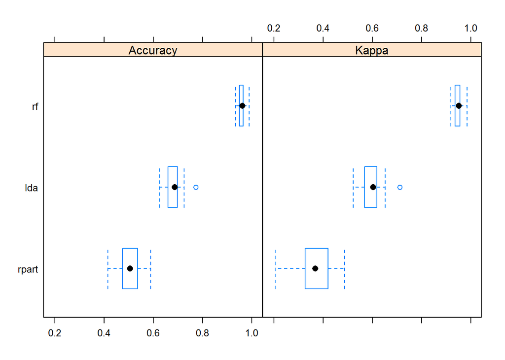

```r
# boxplot comparison
bwplot(compareAll)
```

```r
# rf model seems to register highest accuracy in this case
# fit prediction based on rf model to the test dataset
```

Conclusion

In the Random forest prediction model, the most important variables are given as:

```r
varImp(rf.fit)
```

```
## rf variable importance
##
##   only 20 most important variables shown (out of 48)
##
##                      Overall
## roll_belt             100.00
## pitch_forearm          67.17
## yaw_belt               44.11
## magnet_dumbbell_y      39.34
## magnet_dumbbell_z      39.30
## pitch_belt             30.00
## roll_forearm           28.36
## roll_dumbbell          23.40
## magnet_belt_z          17.30
## magnet_belt_y          17.12
## roll_arm               15.47
## accel_dumbbell_y       15.34
## total_accel_dumbbell   14.97
## magnet_forearm_z       14.27
## magnet_dumbbell_x      13.87
## accel_dumbbell_z       12.33
## accel_belt_z           11.59
## magnet_belt_x          10.80
## magnet_arm_z           10.73
## accel_forearm_x        10.61
```

Below is the result of the prediction on test dataset using the random forest model.

```r
testing<-testRaw
rfpredict<-predict(rf.fit,testing)
rfpredict
```

```
##  [1] B A B A A E D B A A B C B A E E A B A B
## Levels: A B C D E
```